# Senior Thesis

Conceptualizing Death: How Individual Differences Influence Belief in the Afterlife

## **Where did my data come from?**

Using a combination of online questionnaires and in-person interviews, I *painstakingly* collected data from 114 participants over the course of several months.

The resulting demographic information, political/religious beliefs, and afterlife belief scores are stored in the accompanying CSV file.

## **What libraries were used?**

- **stats**: needed to calculate correlations and perform regression analysis
- **plyr and dplyr**: used to clean and organize data
- **ggplot2**: plotting
- **xtable**: saves a lot of frustration when formatting LaTeX tables

## **Preparing the data**

#### Decide which variables to include

I completed my study having collected 32 measures. In hindsight, however, many don’t play into a person’s afterlife belief. I only want to incorporate variables that are relevant/important (backed by research, theories, etc.).

```r
#filter for adults
afterlife.adultdata <- filter(afterlife.data, Adult == 1)

colnames(afterlife.adultdata)
```

```
##  [1] "Part"                    "Age"
##  [3] "Age_Group"               "Adult"
##  [5] "Country"                 "Prime"
##  [7] "HDT"                     "Bio_SummScore"
##  [9] "Psych_SummScore"         "TotalCessation"
## [11] "MoreMind"                "MoreBody"
## [13] "EqualMindBody"           "ResponseType"
## [15] "BeliefLevel"             "Belief_Score"
## [17] "Religion"                "Religion_edited"
## [19] "Religiosity"             "ReligiousBehavior_Score"
## [21] "ReligiousFund_Score"     "Intrinsic_Score"
## [23] "Extrinsic_Summ"          "ExtrinsicSocial_Score"
## [25] "ExtrinsicPersonal_Score" "ReligiousCommit_Score"
## [27] "PoliticalID"             "CRT_Score"
## [29] "Education"               "Ethnicity"
## [31] "Income"                  "Political"
```

```r
#remove irrelevant variable from adultdata
afterlife.adultdata <- afterlife.adultdata[,-c(7)]

#convert all necessary variables to factor types
afterlife.adultdata[,c(6,17,26,27,28,30)] <- colwise(as.factor)(afterlife.adultdata[,c(6,17,26,27,28,30)])

#only keep variables wanted in model
afterlife.adultdata <- afterlife.adultdata[,c(6,15,17,19,20,21,23,24,25,26,28,30)]
```

#### What’s left are the measures I believe are the best predictors for afterlife belief.

```
##  [1] "Prime"                   "Belief_Score"
##  [3] "Religion_edited"         "ReligiousBehavior_Score"
##  [5] "ReligiousFund_Score"     "Intrinsic_Score"
##  [7] "ExtrinsicSocial_Score"   "ExtrinsicPersonal_Score"
##  [9] "ReligiousCommit_Score"   "PoliticalID"
## [11] "Education"               "Income"
```

#### Check for multicollinearity and get rid of offenders.

Religious Behavior needs to go

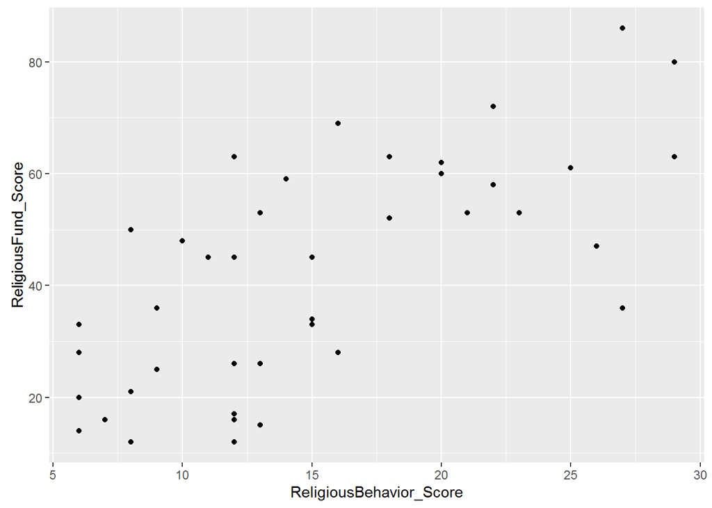

r = 0.6908724

Religious Commitment needs to go

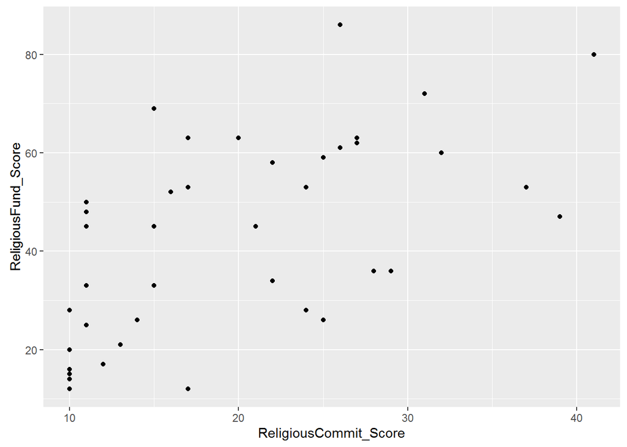

r = 0.6041354

#### Here I realize that my data is regrettably sparse. I need to modify some of the variable groups so they are less specific.

```r
#Political ideology
afterlife.adultdata <- afterlife.adultdata %>%
  mutate(PoliticalBelief = ifelse(PoliticalID == 1 | PoliticalID == 2 | PoliticalID == 3, "liberal",
                                  ifelse(PoliticalID == 4, "moderate", "conservative")))
afterlife.adultdata$PoliticalBelief = as.factor(afterlife.adultdata$PoliticalBelief)
#Education
afterlife.adultdata <- afterlife.adultdata %>%
  mutate(Education_Macro = ifelse(Education == 5 | Education == 6, "College",
                                  "High school or below"))
afterlife.adultdata$Education_Macro <- as.factor(afterlife.adultdata$Education_Macro)
#Income
afterlife.adultdata <- afterlife.adultdata %>%
  mutate(Income_Macro = ifelse(Income == 1 | Income == 2, "40,000 or less",
                               ifelse(Income == 3 | Income == 4, "40,001 to 90,000","90,000 or more")))
afterlife.adultdata$Income_Macro <- as.factor(afterlife.adultdata$Income_Macro)
```

#### Data is ready! Variables to include in model:

```
##  [1] "Prime"                   "Belief_Score"
##  [3] "Religion_edited"         "ReligiousFund_Score"
##  [5] "Intrinsic_Score"         "ExtrinsicSocial_Score"
##  [7] "ExtrinsicPersonal_Score" "PoliticalID"
##  [9] "Education"               "Income"
## [11] "PoliticalBelief"         "Education_Macro"
## [13] "Income_Macro"
```

## **Building the regression models**

#### My study involved a priming condition, so I want to compare a model that accounts for prime interactions with one that does not.

```
##
## Call:
## lm(formula = Belief_Score ~ Prime + ReligiousFund_Score + ExtrinsicSocial_Score +
##     ExtrinsicPersonal_Score + PoliticalBelief + Income_Macro,
##     data = afterlife.adultdata)
##
## Residuals:
##     Min      1Q  Median      3Q     Max
## -3.8275 -1.4691  0.1358  1.3142  3.5521
##
## Coefficients:
##                              Estimate Std. Error t value Pr(>|t|)
## (Intercept)                  -4.12706    1.91909  -2.151 0.039171 *
## Prime2                        2.79255    0.72329   3.861 0.000517 ***
## ReligiousFund_Score           0.05709    0.02146   2.661 0.012090 *
## ExtrinsicSocial_Score         0.30413    0.13702   2.220 0.033651 *
## ExtrinsicPersonal_Score       0.14836    0.14601   1.016 0.317206
## PoliticalBeliefliberal        0.33478    0.95036   0.352 0.726948
## PoliticalBeliefmoderate      -0.50841    1.05146  -0.484 0.632013
## Income_Macro40,001 to 90,000  0.34035    0.99213   0.343 0.733804
## Income_Macro90,000 or more    0.83862    1.01511   0.826 0.414840
## ---
## Signif. codes:  0 '***' 0.001 '**' 0.01 '*' 0.05 '.' 0.1 ' ' 1
##
## Residual standard error: 2.255 on 32 degrees of freedom
## Multiple R-squared:  0.5191, Adjusted R-squared:  0.3989
## F-statistic: 4.318 on 8 and 32 DF,  p-value: 0.001309
```

```
##
## Call:
## lm(formula = Belief_Score ~ Prime + ReligiousFund_Score + Intrinsic_Score +
##     ExtrinsicSocial_Score + ExtrinsicPersonal_Score + PoliticalBelief +
##     Income_Macro + Prime * ReligiousFund_Score + Prime * Intrinsic_Score +
##     Prime * ExtrinsicSocial_Score + Prime * ExtrinsicPersonal_Score +
##     Prime * PoliticalBelief + Prime * Income_Macro, data = afterlife.adultdata)
##
## Residuals:
##     Min      1Q  Median      3Q     Max
## -3.7677 -1.0140 -0.0343  1.0680  2.6312
##
## Coefficients:
##                                     Estimate Std. Error t value Pr(>|t|)
## (Intercept)                         -2.92618    3.24071  -0.903   0.3759
## Prime2                               2.68286    4.71345   0.569   0.5747
## ReligiousFund_Score                  0.02090    0.03264   0.640   0.5283
## Intrinsic_Score                      0.06853    0.10682   0.642   0.5275
## ExtrinsicSocial_Score                0.14171    0.18609   0.762   0.4541
## ExtrinsicPersonal_Score              0.27266    0.17919   1.522   0.1417
## PoliticalBeliefliberal               1.54561    1.20797   1.280   0.2135
## PoliticalBeliefmoderate              1.39490    1.30847   1.066   0.2975
## Income_Macro40,001 to 90,000        -2.72184    1.38591  -1.964   0.0617 .
## Income_Macro90,000 or more          -1.80694    1.40765  -1.284   0.2120
## Prime2:ReligiousFund_Score           0.08944    0.04645   1.925   0.0666 .
## Prime2:Intrinsic_Score              -0.07911    0.17051  -0.464   0.6470
## Prime2:ExtrinsicSocial_Score         0.59366    0.27153   2.186   0.0392 *
## Prime2:ExtrinsicPersonal_Score      -0.75567    0.28875  -2.617   0.0154 *
## Prime2:PoliticalBeliefliberal       -2.47571    1.88660  -1.312   0.2024
## Prime2:PoliticalBeliefmoderate      -3.20893    2.06923  -1.551   0.1346
## Prime2:Income_Macro40,001 to 90,000  4.30787    1.78248   2.417   0.0240 *
## Prime2:Income_Macro90,000 or more    5.06730    1.89326   2.676   0.0135 *
## ---
## Signif. codes:  0 '***' 0.001 '**' 0.01 '*' 0.05 '.' 0.1 ' ' 1
##
## Residual standard error: 1.88 on 23 degrees of freedom
## Multiple R-squared:  0.7598, Adjusted R-squared:  0.5822
## F-statistic: 4.279 on 17 and 23 DF,  p-value: 0.0007432
```

#### xtable works wonders for converting R tables into LaTeX format

```r
## function for printing a pretty table in latex later


print.xtable.booktabs <- function(x){

  print(xtable(x),
        floating=F,
        hline.after=NULL,
        add.to.row=list(pos=list(-1,0, nrow(x)),
                        command=c(
                          '\\toprule\n',
                          '\\midrule\n',
                          '\\bottomrule\n')))

}

## prepare the adult data
lm.table <- xtable(summary(overall.adult.model2))
print.xtable.booktabs(lm.table)
```

```
## % latex table generated in R 3.2.4 by xtable 1.8-2 package
## % Mon Mar 21 22:29:06 2016
## \begin{tabular}{rrrrr}
##   \toprule
##  & Estimate & Std. Error & t value & Pr($>$$|$t$|$) \\
##   \midrule
## (Intercept) & -2.93 & 3.24 & -0.90 & 0.38 \\
##   Prime2 & 2.68 & 4.71 & 0.57 & 0.57 \\
##   ReligiousFund\_Score & 0.02 & 0.03 & 0.64 & 0.53 \\
##   Intrinsic\_Score & 0.07 & 0.11 & 0.64 & 0.53 \\
##   ExtrinsicSocial\_Score & 0.14 & 0.19 & 0.76 & 0.45 \\
##   ExtrinsicPersonal\_Score & 0.27 & 0.18 & 1.52 & 0.14 \\
##   PoliticalBeliefliberal & 1.55 & 1.21 & 1.28 & 0.21 \\
##   PoliticalBeliefmoderate & 1.39 & 1.31 & 1.07 & 0.30 \\
##   Income\_Macro40,001 to 90,000 & -2.72 & 1.39 & -1.96 & 0.06 \\
##   Income\_Macro90,000 or more & -1.81 & 1.41 & -1.28 & 0.21 \\
##   Prime2:ReligiousFund\_Score & 0.09 & 0.05 & 1.93 & 0.07 \\
##   Prime2:Intrinsic\_Score & -0.08 & 0.17 & -0.46 & 0.65 \\
##   Prime2:ExtrinsicSocial\_Score & 0.59 & 0.27 & 2.19 & 0.04 \\
##   Prime2:ExtrinsicPersonal\_Score & -0.76 & 0.29 & -2.62 & 0.02 \\
##   Prime2:PoliticalBeliefliberal & -2.48 & 1.89 & -1.31 & 0.20 \\
##   Prime2:PoliticalBeliefmoderate & -3.21 & 2.07 & -1.55 & 0.13 \\
##   Prime2:Income\_Macro40,001 to 90,000 & 4.31 & 1.78 & 2.42 & 0.02 \\
##   Prime2:Income\_Macro90,000 or more & 5.07 & 1.89 & 2.68 & 0.01 \\
##    \bottomrule
## \end{tabular}
```